# ML_HW6

2022-11-19

Please click [here](https://github.com/Donovan-Rasamoelison/Machine_learning_HW6) for the link to the github repository.

```r
library(tidyverse)
library(tidymodels)
library(janitor)
library(discrim)
library(corrplot)
library(klaR)
library(glmnet)
library(yardstick)
library(rpart.plot)
library(vip)
library(randomForest)
library(xgboost)
library(ranger)

set.seed(0)
```

# Coding questions

## Question 1 - using clean_names() on pokemon data

```r
pokemon <- read.csv("Pokemon.csv") %>% clean_names()

pokemon %>% count("Pokemon type" = fct_reorder(as.factor(type_1),type_1,.fun='length')) # looking at the number of types and the types with few observation
```

```
##    Pokemon type   n
## 1        Flying   4
## 2         Fairy  17
## 3           Ice  24
## 4      Fighting  27
## 5         Steel  27
## 6        Poison  28
## 7          Dark  31
## 8        Dragon  32
## 9         Ghost  32
## 10       Ground  32
## 11     Electric  44
## 12         Rock  44
## 13         Fire  52
## 14      Psychic  57
## 15          Bug  69
## 16        Grass  70
## 17       Normal  98
## 18        Water 112
```

```r
pokemon_clean <- pokemon %>%
  filter(type_1 %in% c("Bug","Fire","Grass","Normal","Water","Psychic")) %>% #filtering to only include selected types
  mutate(across(c(type_1,legendary), ~ as.factor(.))) #making type_1 and legendary factor

#Splitting the data to training and test set
pokemon_split <- initial_split(pokemon_clean, prop = 0.8, strata = "type_1")
pokemon_clean_train <- training(pokemon_split)
pokemon_clean_test  <- testing(pokemon_split)

#V-fold cross validation (k=5)
pokemon_clean_fold <- vfold_cv(pokemon_clean_train, v=5, strata = "type_1")

#creating a recipe
pokemon_clean_recipe <- recipe(formula = type_1 ~ legendary + generation + sp_atk + attack + speed + defense + hp + sp_def, data = pokemon_clean_train) %>%
  step_dummy(legendary, generation) %>%
  step_center(all_predictors()) %>%
  step_normalize(all_predictors())
```

## Question 2 - Correlation matrix of the training set

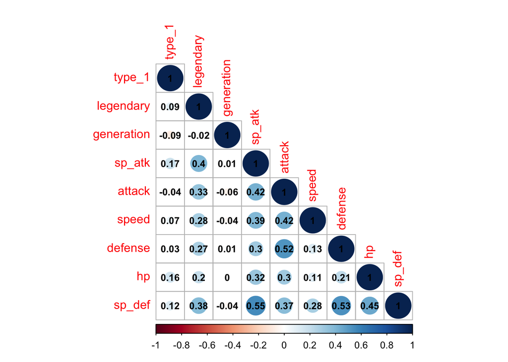

```r
M <- pokemon_clean_train %>% dplyr::select(type_1 , legendary , generation , sp_atk , attack , speed , defense , hp , sp_def) %>%
  mutate(across( c(type_1, legendary), ~as.numeric(.)))

corrplot(round(cor(M),2) ,method = 'circle', type = 'lower', insig='blank', addCoef.col ='black', number.cex = 0.8)
```

Legendary, sp_atk, and attack have higher correlation to most of the variables. This makes sense because it shows the importance of these variables on the strength of the Pokemon.

## Question 3 - Decision tree model

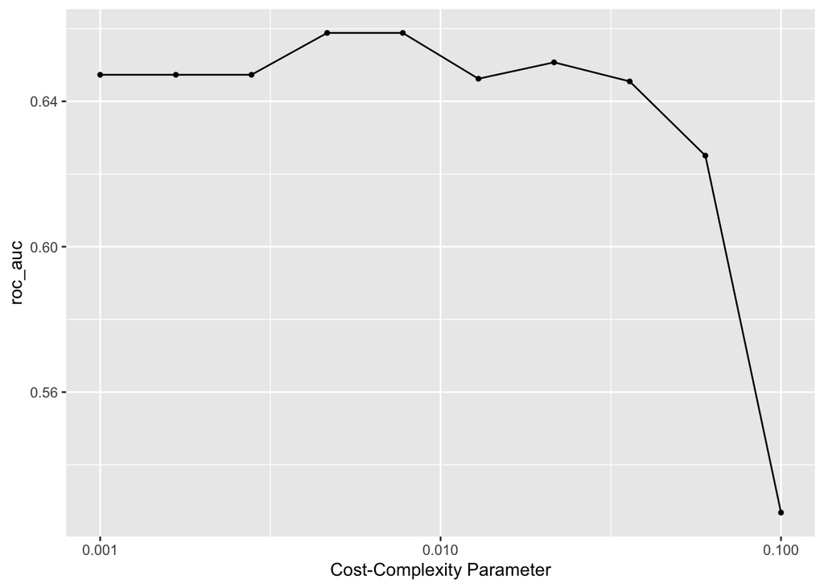

```r
tree_spec <- decision_tree() %>% set_engine("rpart")
class_tree_spec <- tree_spec %>% set_mode("classification")

#setting the workflow tuning cost_complexity
class_tree_wf <- workflow() %>%
  add_model(class_tree_spec %>% set_args(cost_complexity = tune())) %>%
  add_recipe(pokemon_clean_recipe)

#creating a grid of values for cost_complexity
param_grid <- grid_regular(cost_complexity(range = c(-3,-1)), levels = 10)

#fitting the models on the validation folds
tune_res <- tune_grid(
  class_tree_wf,
  resamples = pokemon_clean_fold,
  grid = param_grid,
  metrics = metric_set(roc_auc)
)

autoplot(tune_res)
```

We observe that the single decision tree performs better with smaller complexity values.

## Question 4 - ROC_AUC of the best performing model

```r
collect_metrics(tune_res) %>% arrange(desc(mean))
```

```
## # A tibble: 10 × 7
##    cost_complexity .metric .estimator  mean     n std_err .config
##              <dbl> <chr>   <chr>      <dbl> <int>   <dbl> <chr>
##  1         0.00464 roc_auc hand_till  0.659     5 0.0166  Preprocessor1_Model04
##  2         0.00774 roc_auc hand_till  0.659     5 0.0166  Preprocessor1_Model05
##  3         0.0215  roc_auc hand_till  0.651     5 0.00434 Preprocessor1_Model07
##  4         0.001   roc_auc hand_till  0.647     5 0.0224  Preprocessor1_Model01
##  5         0.00167 roc_auc hand_till  0.647     5 0.0224  Preprocessor1_Model02
##  6         0.00278 roc_auc hand_till  0.647     5 0.0224  Preprocessor1_Model03
##  7         0.0129  roc_auc hand_till  0.646     5 0.0204  Preprocessor1_Model06
##  8         0.0359  roc_auc hand_till  0.645     5 0.0104  Preprocessor1_Model08
##  9         0.0599  roc_auc hand_till  0.625     5 0.00400 Preprocessor1_Model09
## 10         0.1     roc_auc hand_till  0.527     5 0.0269  Preprocessor1_Model10
```

The roc_auc of the best performing pruned decision tree is 0.658.

## Question 5 - fitting and visualizing best performing decision tree

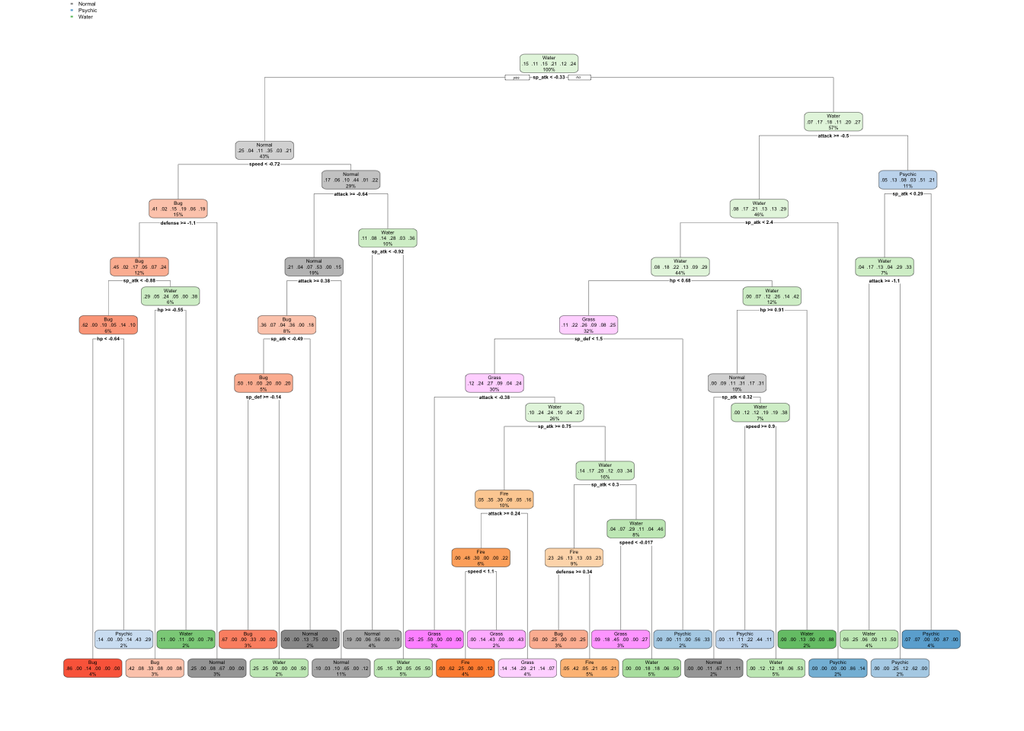

```r
best_complexity <- select_best(tune_res, metric = "roc_auc")
class_tree_final <- finalize_workflow(class_tree_wf, best_complexity)

class_tree_final_fit <- fit(class_tree_final, data = pokemon_clean_train)
class_tree_final_fit %>%
  extract_fit_engine() %>%
  rpart.plot()
```

## Question 5 - Setting up Random forest

```r
rf_spec <- rand_forest(mtry = tune(),trees = tune(), min_n = tune() ) %>%
  set_engine("ranger", importance = "impurity") %>%
  set_mode("classification")

#setting up workflow
rf_wf <- workflow() %>%
  add_model(rf_spec) %>%
  add_recipe(pokemon_clean_recipe)

#Creating regular grids
model_grid <- grid_regular(mtry(range = c(1,8)), trees(range = c(10,2000)), min_n(range = c(10,80)), levels = 8)
```

Definition of the variables to be tuned:

mtry = number of predictors that will be randomly sampled at each split when creating tree models.

trees = the number of trees.

min_n = minimum number of data points in a node that are required for the node to be split further.

mtry cannot be less than 1 or larger than 8 for this model because 8 is the total numbers of predictors, and at least 1 predictor must be used. mtry = 8 represents a bagging model.

## Question 6 - tuning the Random Forest model

```r
tune_res_rf <- tune_grid(
  rf_wf,
  resamples = pokemon_clean_fold,
  grid = model_grid,
  metrics = metric_set(roc_auc)
)
#Save tune_res_rf as an R object to not run it again when knitting
saveRDS(tune_res_rf, file="tune_res_rf_saved.RData")
```

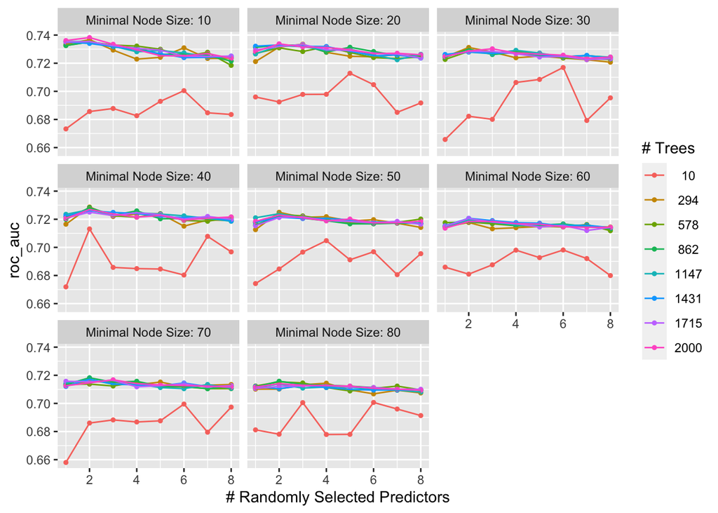

```r
tune_res_rf_saved <- readRDS("tune_res_rf_saved.RData")
autoplot(tune_res_rf_saved)
```

```r
select_best(tune_res_rf_saved, metric = "roc_auc")
```

```
## # A tibble: 1 × 4
##    mtry trees min_n .config
##   <int> <int> <int> <chr>
## 1     2  2000    10 Preprocessor1_Model058
```

The roc_auc of the different models on the folds seems to converge when the number of trees is high (more than 300).

## Question 7 - ROC_AUC of the best performing Random Forest model

```r
collect_metrics(tune_res_rf_saved) %>% arrange(desc(mean))
```

```
## # A tibble: 512 × 9
##     mtry trees min_n .metric .estimator  mean     n std_err .config
##    <int> <int> <int> <chr>   <chr>      <dbl> <int>   <dbl> <chr>
##  1     2  2000    10 roc_auc hand_till  0.738     5  0.0119 Preprocessor1_Model…
##  2     2   294    10 roc_auc hand_till  0.737     5  0.0138 Preprocessor1_Model…
##  3     1  2000    10 roc_auc hand_till  0.736     5  0.0113 Preprocessor1_Model…
##  4     1  1147    10 roc_auc hand_till  0.735     5  0.0107 Preprocessor1_Model…
##  5     2  1147    10 roc_auc hand_till  0.735     5  0.0126 Preprocessor1_Model…
##  6     2  1715    10 roc_auc hand_till  0.735     5  0.0117 Preprocessor1_Model…
##  7     2   578    10 roc_auc hand_till  0.735     5  0.0137 Preprocessor1_Model…
##  8     1  1715    10 roc_auc hand_till  0.735     5  0.0122 Preprocessor1_Model…
##  9     2   862    10 roc_auc hand_till  0.735     5  0.0109 Preprocessor1_Model…
## 10     1  1431    10 roc_auc hand_till  0.735     5  0.0116 Preprocessor1_Model…
## # … with 502 more rows
```

The roc_auc of the best performing Random Forest model is 0.738

## Question 8 - Importance plot of the best performing model

```r
best_complexity_rf <- select_best(tune_res_rf_saved, metric = "roc_auc")
best_complexity_rf
```

```
## # A tibble: 1 × 4
##    mtry trees min_n .config
##   <int> <int> <int> <chr>
## 1     2  2000    10 Preprocessor1_Model058
```

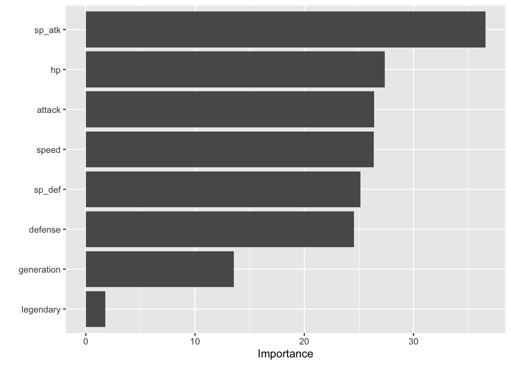

```r
rf_spec_final <- rand_forest(mtry = best_complexity_rf$mtry,trees = best_complexity_rf$trees, min_n = best_complexity_rf$min_n ) %>%
  set_engine("ranger", importance = "impurity") %>%
  set_mode("classification")

rf_fit <- fit(rf_spec_final, type_1 ~ legendary + generation + sp_atk + attack + speed + defense + hp + sp_def, data = pokemon_clean_train)

vip(rf_fit)
```

- sp_atk is the most useful variable.
- legendary is the least useful variable.
- Yes, these results are what I expected because type of pokemon is defined by its special attack.

## Question 9 - Setting a boosted tree model and workflow

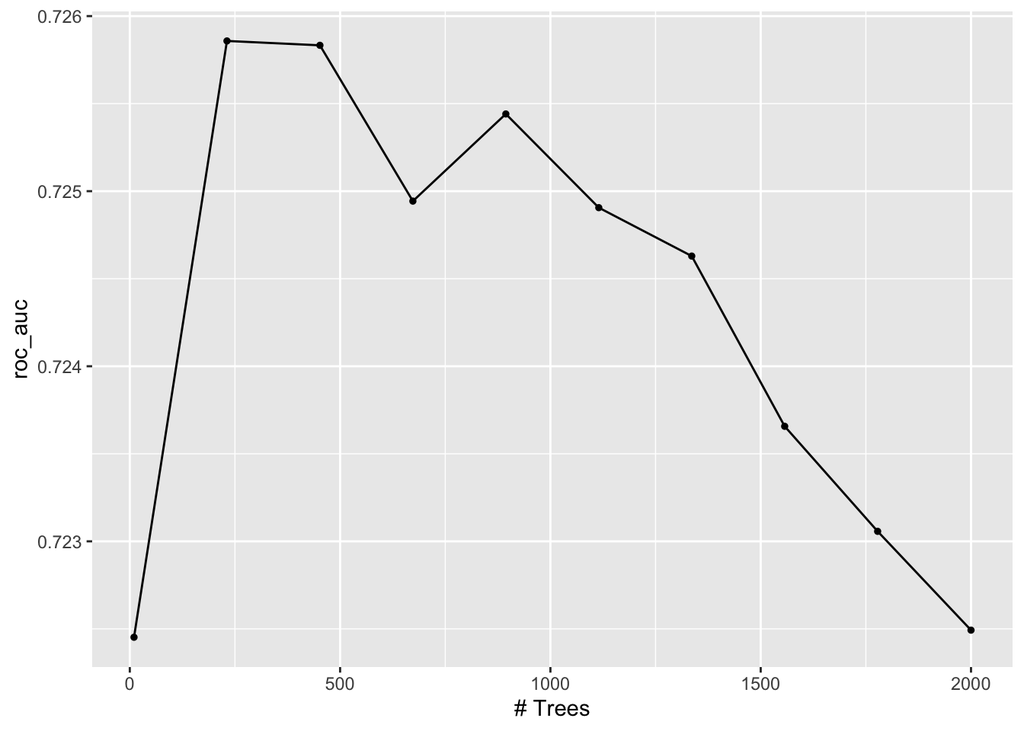

```r
boost_spec <- boost_tree(trees = tune()) %>%
  set_engine("xgboost") %>%
  set_mode("classification")

#Setting up workflow
boost_wf <- workflow() %>%
  add_model(boost_spec) %>%
  add_recipe(pokemon_clean_recipe)

#Creating regular grids
boosted_grid <- grid_regular(trees(range = c(10,2000)), levels = 10)

#tuning the Boosted model
tune_res_boosted <- tune_grid(
  boost_wf,
  resamples = pokemon_clean_fold,
  grid = boosted_grid,
  metrics = metric_set(roc_auc)
)

autoplot(tune_res_boosted)
```

```r
collect_metrics(tune_res_boosted) %>% arrange(desc(mean))
```

```
## # A tibble: 10 × 7
##    trees .metric .estimator  mean     n std_err .config
##    <int> <chr>   <chr>      <dbl> <int>   <dbl> <chr>
##  1   231 roc_auc hand_till  0.726     5  0.0156 Preprocessor1_Model02
##  2   452 roc_auc hand_till  0.726     5  0.0158 Preprocessor1_Model03
##  3   894 roc_auc hand_till  0.725     5  0.0157 Preprocessor1_Model05
##  4   673 roc_auc hand_till  0.725     5  0.0155 Preprocessor1_Model04
##  5  1115 roc_auc hand_till  0.725     5  0.0154 Preprocessor1_Model06
##  6  1336 roc_auc hand_till  0.725     5  0.0157 Preprocessor1_Model07
##  7  1557 roc_auc hand_till  0.724     5  0.0154 Preprocessor1_Model08
##  8  1778 roc_auc hand_till  0.723     5  0.0151 Preprocessor1_Model09
##  9  2000 roc_auc hand_till  0.722     5  0.0151 Preprocessor1_Model10
## 10    10 roc_auc hand_till  0.722     5  0.0162 Preprocessor1_Model01
```

I observe that roc_auc is increasing at low numbers of trees then starts to decrease. The ROC_AUC of the best performing Boosted model is 0.725

## Question 10 - Selecting the final best model

```r
#A table comparing the roc_auc
model <- c("Pruned tree","Random Forest","Boosted tree")
roc_auc_model <- c( 0.658, 0.738, 0.725)
tibble(model, roc_auc_model)
```

```
## # A tibble: 3 × 2
##   model         roc_auc_model
##   <chr>                 <dbl>
## 1 Pruned tree           0.658
## 2 Random Forest         0.738
## 3 Boosted tree          0.725
```

```r
#fitting the best model (=Random Forest) on the test set
best_tuned <- select_best(tune_res_rf_saved, metric = "roc_auc")
best_model_final_wf <- finalize_workflow(rf_wf, best_tuned)
best_model_fit <- fit(best_model_final_wf, data = pokemon_clean_test)

#ROC AUC for the testing set
augment(best_model_fit, new_data = pokemon_clean_test) %>% roc_auc(truth = type_1, estimate = .pred_Bug:.pred_Water)
```

```
## # A tibble: 1 × 3
##   .metric .estimator .estimate
##   <chr>   <chr>          <dbl>
## 1 roc_auc hand_till      0.997
```

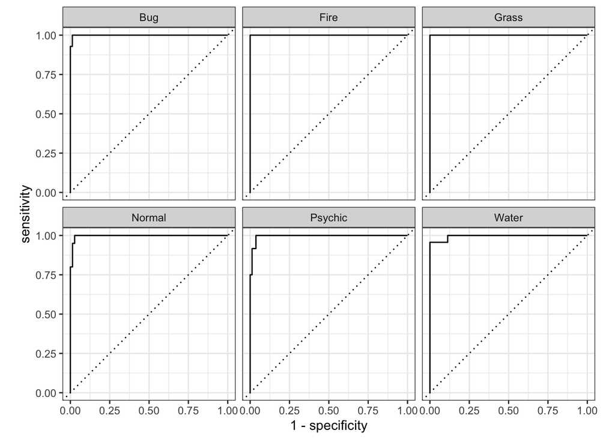

```r
#ROC for each level of the outcome
augment(best_model_fit, new_data = pokemon_clean_test) %>% roc_curve(truth = type_1, estimate = .pred_Bug:.pred_Water) %>% autoplot()
```

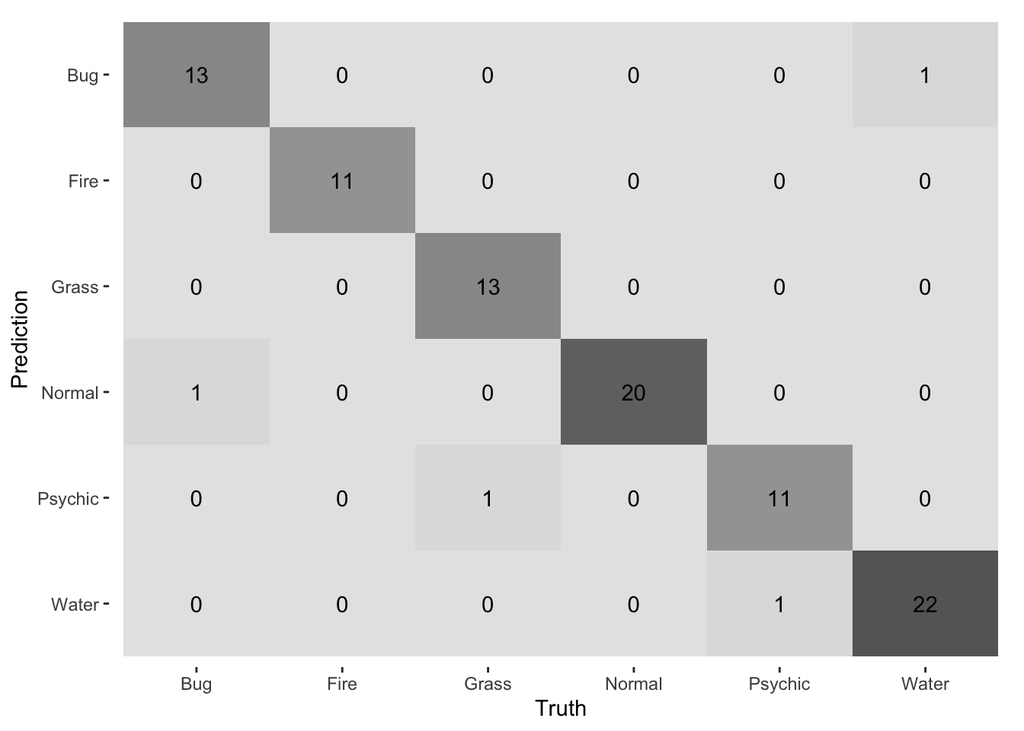

```r
#heatmap of the confusion matrix
augment(best_model_fit, new_data = pokemon_clean_test) %>% conf_mat(truth = type_1, estimate = .pred_class) %>% autoplot(type = "heatmap")
```

## Question 11 - 231 students only

Fitting a Random Forest model on abalone data.

```r
abalone <- read_csv("abalone.csv")

abalone <- abalone %>%
  mutate(age = rings + 1.5)

abalone <- abalone %>%
  dplyr::select(-c(rings))

#splitting the data
abalone_split <- initial_split(abalone, prop = 0.80, strata = age)
abalone_train <- training(abalone_split)
abalone_test  <- testing(abalone_split)

#setting recipe from abalone (HW2)
abalone_recipe <- recipe(age ~ ., data = abalone_train) %>%
  step_dummy(all_nominal_predictors()) %>%
  step_interact(terms = ~ type_M:shucked_weight) %>%
  step_interact(terms = ~ longest_shell:diameter) %>%
  step_interact(terms = ~ shucked_weight:shell_weight) %>%
  step_center(all_predictors()) %>%
  step_scale(all_predictors())

#V-fold cross validation (k=510
abalon_fold <- vfold_cv(abalone_train, v=10, strata = "age")

#setting up random forest model
abalone_spec <- rand_forest(mtry = tune(),trees = tune(), min_n = tune() ) %>%
  set_engine("ranger", importance = "impurity") %>%
  set_mode("regression")

#setting up workflow
abalone_wf <- workflow() %>%
  add_model(abalone_spec) %>%
  add_recipe(abalone_recipe)

#Creating regular grids
abalone_grid <- grid_regular(mtry(range = c(1,8)), trees(range = c(10,2000)), min_n(range = c(10,80)), levels = 8)
```

```r
#fitting the model on the cross validation folds
abalone_res_rf <- tune_grid(
  abalone_wf,
  resamples = abalon_fold,
  grid = abalone_grid
  )

#Save abalone_res_rf as an R object to not run it again when knitting
saveRDS(abalone_res_rf, file="abalone_res_rf_saved.RData")
```

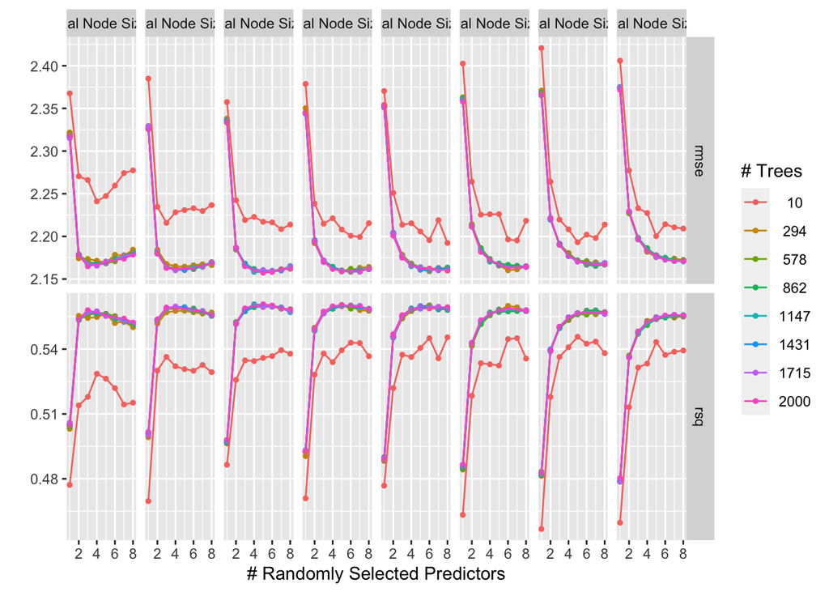

```r
abalone_res_rf_saved <- readRDS("abalone_res_rf_saved.RData")
autoplot(abalone_res_rf_saved)
```

```r
#Selecting best model and finalizing workflow
best_abalone <- select_best(abalone_res_rf_saved)
abalone_wf_final <- finalize_workflow(abalone_wf , best_abalone)

#fitting on the test set
abalone_best_model_fit <- fit(abalone_wf_final, data = abalone_test)

#RMSE for the testing set
rmse <- augment(abalone_best_model_fit, new_data = abalone_test) %>% rmse(truth = age, estimate = .pred)
rmse
```

```
## # A tibble: 1 × 3
##   .metric .estimator .estimate
##   <chr>   <chr>          <dbl>
## 1 rmse    standard        1.65
```

The model’s RMSE on the testing set is rmse, standard, 1.6537603.